# GWAS Bootcamp

Genotype and Dosage Calling

Felipe Ferrão

University of Florida – July, 2022

**Objectives:**

- 40 minutes of hands-on
- Using R for analyses of genotyping and dosage calling

**Extra information**

- [HOS 6932 – Website](https://lfelipe-ferrao.github.io/class/survey/)
- About the [author](https://lfelipe-ferrao.github.io/)
- About the [UF/IFAS Plant Breeding](https://programs.ifas.ufl.edu/plant-breeding/)

# Preface

Collecting genomic data goes beyond the tutorial presented here. As a sake of time, we are skipping many important steps related to field data collection, DNA extraction, SNP identification, definition of the genotyping platform, analyzes using clusters (or supercomputers), cluster organization and other bioinformatic routines that are required.

In the blueberry breeding lab, **Juliana Benevenuto** has been leading these activities. If you’re interested in this part, contact her. My personal view on this area: learning a programming language and how to work in a UNIX environment are two of my top suggestions. For more details on how we defined the genotyping platform used in our blueberry studies, see the paper presented by [Benevenuto et al., (2019)](https://academic.oup.com/gigascience/article/8/6/giz068/5513659?guestAccessKey=6ff2ddb4-148b-44a7-970a-1c1a9f394200&login=true) and further discussion presented by [Ferrão et al., 2021](https://www.frontiersin.org/articles/10.3389/fpls.2021.676326/full).

# Introduction

Any analysis of association between genotype and phenotype starts with the collection of good phenotypic data and adequate statistical analysis for associating the phenotypic variation at the molecular level. In the last tutorial, we discussed the importance of using statistical methods to approach the phenotypic data. The second important piece of information is to obtain variants at the genetic level.

This tutorial addresses the importance of quantifying genetic variation at the population level. **By genetic variation, we mean differences in DNA content or structure among individuals.** As an example, it is estimated that there are more than 100,000,000 know genetic variants in the human genome. When such variations are accessed, we can, for example, differente humans based on genetic information. Variation at the DNA level can be classified in different ways, including as Single-nucleotide polymorphims (**SNPs**), insertion-deletion polymorphisms (**indels**) and structural variants (**SV**).

Quantify such variation by measuring allelic variations within a locus is called **genotyping**. We will not present details on how to obtain molecular markers for genotyping. But in general, the process of genotyping can be carried out using sequencig methods or arrays.

**Sequencing** methods we can divide in four main phases:

1. sequencing and obtaining the FASTQ files;
2. align to a reference genome;
3. identify genetic variants;
4. count the number of reads with each allele to perform the genotyping calling.
- Examples of sequencing methods include whole-genome sequencing, GBS methods, CaptureSeq and other variations of GBS approach.

For **genotyping array**, we can also divide in four main stepes:

1. each spot on array is targeting specific SNPs;
2. DNA fragment attach to spot;
3. each allele is labelled with a different color;
4. fluorescence of both alleles are capture and used for genotyping calling.
- Examples of arrays includes KASP markers, Sequenom MASSArray, Illumina GoldenGate.

Both methods have one task in common for polyploid analyses: **after identified the genetic variants across the genome we need to compute the the allelic dosage to assign the genotypic class of a given individual**. In this tutorial we will focus on sequencing methods, but the principle to assign allele dosages in arrays is very similar.

**We will follow the general structure:**

- What is dosage?
- Why is dosage calling more challenging in polyploids?
- From raw data to dosage calling, how to define the genotypic class in tetraploid
- `updog` package
  - Admixture population
  - Biparental population
- `vcf` file
- Genomic matrix (input for GWAS analyses)

## Overview of Dosage Calling

Look the example below:

- We are using a genotyping-by-sequencing method to differentiate 3 individuals
- For this chr we could find 10 SNPs
- We are investigating two loci (SNP4 and SNP10)
- Diploid species (2n=2x)
- Task: determine the genotype classes for the individuals for both loci

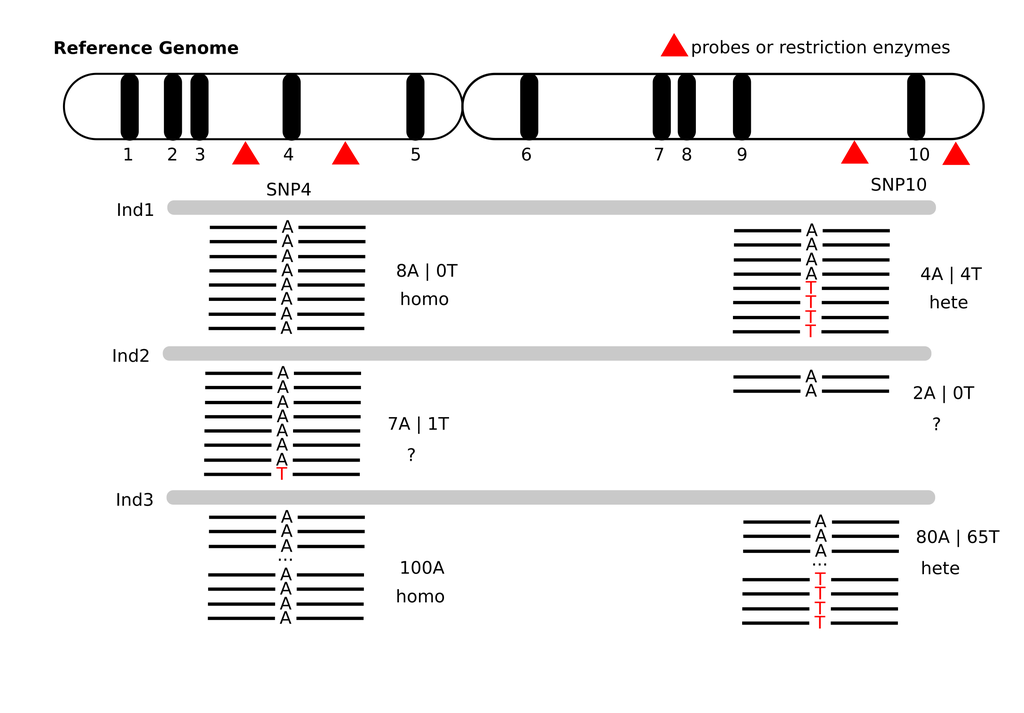

**Observations**

- By dosage we mean the count of one allele at one marker (position) in one individual
- The example refers to a diploid species
- It seems clear that individual 1 is well genotyped for both SNPs, correct? There is good coverage of the sampled alleles.
- And about the individual 2? For SNP4, the T allele, is it a true variation or perhaps a sequencing error? Would this genotype be homozygous or heterozygous? And about the SNP10, there is a low coverage !
- Ind 3 was massively sequenced. When compared with Ind 1, for example, which of the two individuals for both SNPs are presenting more evidences about the real genotype?

**Conclusion**

- Genotyping is equivalent to associating the allele dosage on a given locus to this genotype by considering the proportion of reference and alternative alleles sequenced.

### Example sequencing data

See the example below:

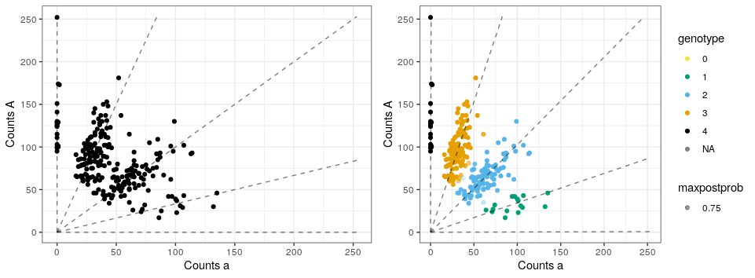

Example of a good SNP

- This scatterplot represents a single SNP, in blueberry.
- Each point is an individual.
- The x-axis is the number of “a” reads and the y-axis is the number “A” reads.
- The five lines jutting out from (0,0) represent the expected counts at each of the five possible genotypes for a tetraploid individual.

**Can you define the genotypes of each individual in the population?**

- The bottom right line is the expected counts for an individual with four copies of “a” (aaaa), the next line up is for individuals with tree copies of “a” (Aaaa), then two copies (AAaa), etc.
- Common nomenclature:
  - quadruplex (AAAA),
  - triplex (Aaaa),
  - duplex (AAaa),
  - simplex (Aaaa),
  - nulliplex (aaaa)
- Genotyping is equivalent to associating each point on this genotype plot with the line it belongs to. In the above plot, making this determination is relatively easy.
- This example is simple, because this SNP has a good point cloud pattern within the expected lines. Technically, we don’t need a statistical method to classify genotypes.

**But there is no free lunch in Science …**

And about the example below:

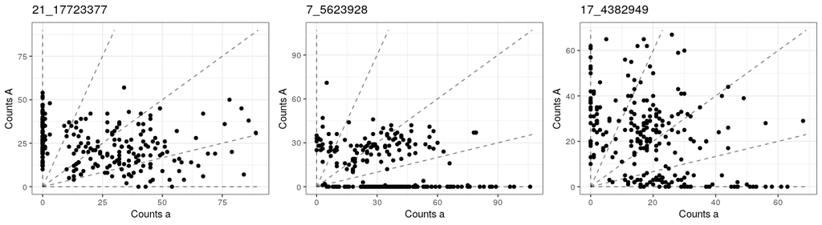

Example of bad SNPs

- There is a confusion in the point cloud for the three SNPs under evaluation.
- Which line do they belong?
- SNPs with this messy pattern is **very common** in polyploid data sets.
- We had to deal with some issues present in sequencing data: bias, overdispersion, and outlying points; that has biological and technical causes.

### `updog` package

- Updog provides a suite of methods for genotyping polyploids from next-generation sequencing (NGS) data. It does this while accounting for many common features of NGS data: allele bias, overdispersion, and sequencing error.
- The method is described in detail [Gerard et. al. (2018)](https://academic.oup.com/genetics/article/210/3/789/5931034?etoc)
- Additional details concerning prior specification are described in [Gerard and Ferrão (2020)](https://academic.oup.com/bioinformatics/article/36/6/1795/5625617?login=true)
- More intuive explanation you can find [here](http://dcgerard.github.io/research/2018/03/16/updog.html)
- [Github](https://github.com/dcgerard/updog) of the package.

**The model**

$$[\tilde{y}_i|\tilde{n}_j,\tilde{p}_j= l_j/K,\epsilon, h,\tau, \pi]$$
$$\sim \pi BB(\tilde{n}_j, \xi (l_j/K,\epsilon,h),\tau) + (1-\pi)BB(N-j,1/2,1/3)$$
$$\sum^{k_i}_{j=0} HG \left (j, \frac{k}{2} \mid l_1,K) HG(k_i-j, \frac{k}{2} | l_2,K \right)$$
$$logit(\epsilon) \sim N(\mu_e,\sigma^2_e)$$
$$log(h) \sim N(\mu_h, \sigma^2_h)$$
**Intuitively**

- In theory: software will estimate error, bias, overdispersion parameters
- In practice: “Adjusting the expected angles”, given the data and estimated parameters

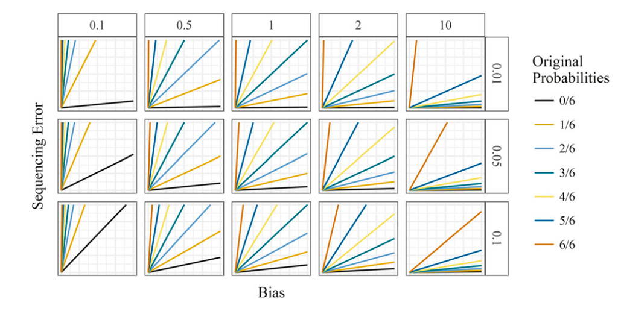

**Why `updog`?**

- Allele dosage calling for any ploidy
- Filter out poor SNPs/individuals
- Estimate preferential paring
- Multiple population designs (flexible prior distributions)
- Simulate genotypes from NGS technologies
- Programmed in R
- Straightforward to run analysis in parallel
- More than 17000 downloads
- Standard method used for different research groups and genotyping companies

# Hands-on

**Two examples**

- Diverse breeding population (admixture), used for GWAS analyses
- Biparental population, used for QTL mapping

## Admixture population

### Overview about vcf files

- Modern genotyping plataform output the results in a `vcf` format
- `vcf` is a text file format that contains meta-information lines, a header line, and then data lines each containing information about a position in the genome.
- Example in a diploid genotype (more detail [here](http://augustogarcia.me/statgen-esalq/Hapmap-and-VCF-formats-and-its-integration-with-onemap/)):

```
##fileformat=VCFv4.0
##fileDate=20160306
##source="Stacks v1.37"
##INFO=<ID=NS,Number=1,Type=Integer,Description="Number of Samples With Data">
##INFO=<ID=AF,Number=.,Type=Float,Description="Allele Frequency">
##FORMAT=<ID=GT,Number=1,Type=String,Description="Genotype">
##FORMAT=<ID=DP,Number=1,Type=Integer,Description="Read Depth">
##FORMAT=<ID=AD,Number=1,Type=Integer,Description="Allele Depth">
##FORMAT=<ID=GL,Number=.,Type=Float,Description="Genotype Likelihood">
#CHROM    POS    ID    REF    ALT    QUAL    FILTER    INFO    FORMAT    Parental_1    Parental_2    ID_1    ID_2    ID_3
Chr02    5565755    44509    A    G    .    PASS    .    GT:DP:AD:GL    0/1:31:23,8:.,42.98,.    0/0:13:9,0:.,18.02,.    0/0:30:30,0:.,41.59,.    0/0:27:27,0:.,37.43,.    0/0:25:25,0:.,34.66,.
```

- It is a SNP at chromosome 2 in the position 5565755.
- Reference allele is an A and has one alternative allele G.
- There is no information about the quality of this data collected. It passed through the filter criteria. There is no additional information about it.
- Samples are represented in the order GT:DP:AD:GL (genotype, read depth, allele depth, and genotype likelihood).
- For diploid analyses, in general, we are interested on the `GT` field
  - 0/1 = analogous to Aa
  - 0/0 = analogous to aa
  - 1/1 = analogous to AA

**Software**

- `vcf` files can be very different depending of the software and parameter used to call the molecular markers.
- `vcf` is much more informative than 012 formats. But for genomic selection, most of the softwares require SNPs the 012 format.
- [vcftools](http://vcftools.sourceforge.net/) to run in terminal
- [vcfR](https://knausb.github.io/vcfR_documentation/) to run in R
- Suggestion: use `vcftools` !

### Running `updog`

**1. Extract the read counts**

- In the example, `snps.vcf` is an aoutput from the FreeBayes software

```
./vcftools --vcf ./snps.vcf --extract-FORMAT-info AO --out AO
./vcftools --vcf ./snps.vcf --extract-FORMAT-info RO --out RO
```

**2. Create the input file**

```r
# Selectiung only individuals from Cath Population
load("/home/lferrao/Dropbox (UFL)/classes/gwas_tutorial/2.Genomics/hands_on1/ao_ro_updog.Rdata")
alt[1:5,1:5] # alternative
```

```
##                     1_74957 1_74985 1_130006 1_130024 1_137968
## UFF_192502_P12_WA09      12      58        0       69       11
## UFF_192502_P07_WH05      14      19        0       34        0
## UFF_192502_P10_WH06      13      20        0       58        0
## UFF_192502_P02_WA03      30      55        0       87       15
## UFF_192502_P15_WE07       5       8        0       31        0
```

```r
ref[1:5,1:5] # reference
```

```
##                     1_74957 1_74985 1_130006 1_130024 1_137968
## UFF_192502_P12_WA09      47      19       97       25       81
## UFF_192502_P07_WH05      38      40       59       24       85
## UFF_192502_P10_WH06      24      28       94       45      115
## UFF_192502_P02_WA03      27      14      102       22       74
## UFF_192502_P15_WE07      30      38       93       67       69
```

```r
dp = alt + ref
dp[1:5,1:5] # total depth
```

```
##                     1_74957 1_74985 1_130006 1_130024 1_137968
## UFF_192502_P12_WA09      59      77       97       94       92
## UFF_192502_P07_WH05      52      59       59       58       85
## UFF_192502_P10_WH06      37      48       94      103      115
## UFF_192502_P02_WA03      57      69      102      109       89
## UFF_192502_P15_WE07      35      46       93       98       69
```

```r
ratio = ref/dp
ratio[1:5,1:5] # ratio
```

```
##                       1_74957   1_74985 1_130006  1_130024  1_137968
## UFF_192502_P12_WA09 0.7966102 0.2467532        1 0.2659574 0.8804348
## UFF_192502_P07_WH05 0.7307692 0.6779661        1 0.4137931 1.0000000
## UFF_192502_P10_WH06 0.6486486 0.5833333        1 0.4368932 1.0000000
## UFF_192502_P02_WA03 0.4736842 0.2028986        1 0.2018349 0.8314607
## UFF_192502_P15_WE07 0.8571429 0.8260870        1 0.6836735 1.0000000
```

**Observation:**

- Alternative and reference alleles are called depending of the reference genome
- `ratio` is a good alternative for genomic selection, in particular, if you have good sequencing depth and modeling a proxy for additive effects. For more details, see [de Bem Oliveira et al., (2019)](https://academic.oup.com/g3journal/article/9/4/1189/6028009) and [Ferrão et al., (2021)](https://www.frontiersin.org/articles/10.3389/fpls.2021.676326/full).
- You can use the `ratio` directly in the `rrblup` package for quick GWAS and GS anlyses. This is an interesting step for initial checks
- Before running `updog`, you can remove genotypes with certain level of missing data, or SNPs with rare allele in the population just checking the `ratio`values. With that, you prevent `updog` from wasting computational time on bad quality SNPs

**3. Running `updog`**

- [Tutorial](https://dcgerard.github.io/updog/) for more details about function and input.
- We will run this example only for two SNPs

```r
library(updog)
library(gridExtra)
library(ggplot2)
refmat  <- t(as.matrix(ref)) # dim: marker by individuals
sizemat <- t(as.matrix(dp)) # dim: marker by individuals
ploidy  <- 4

dim(refmat)
```

```
## [1]   10 1790
```

```r
# visualize the raw data
p1=plot_geno(refvec = refmat[1,], sizevec = sizemat[1,], ploidy = ploidy)+
  ggtitle("1_74957")

# Fitting updog
uout <- multidog(refmat = refmat[1:2,],  # only for the SNPq
                sizemat =  sizemat[1:2,],  # only for the SNPq
                model="norm",          # better model for admixture populations
                ploidy  = ploidy,
                nc=4) # number of clusters
```

[output not shown]

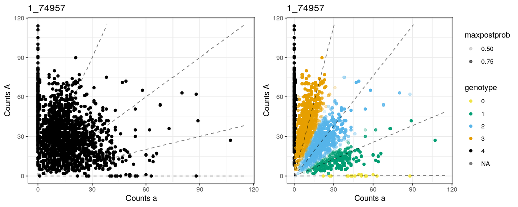

```r
p2 = plot(uout, indices=c(1))

# Ploting both results
grid.arrange(p1,p2[[1]], ncol=2)
```

```r
# Observation
# Individuals that are in the middle of two lines have lower probability associated
```

**4. Output from updog**

- `snpdf`: A data frame containing properties of the SNPs (markers). The rows index the SNPs
- `inddf`: A data frame containing the properties of the individuals at each SNP.
- `bias`: systematic bias toward reference or alternative allele.
- `sequencing error`: homozygous individuals can be erroneously classified as heterozygous.
- `overdispersion`: additional variability in the model
- `prop_miss`: most important metric from `updog` and informs the (posterior) proportion of individuals mis-genotyped

```r
library(updog)
uout$snpdf
```

```
##       snp      bias         seq         od   prop_mis num_iter     llike ploidy
## 1 1_74957 0.7890442 0.002480926 0.01266881 0.10235688       56 -6087.204      4
## 2 1_74985 0.8598156 0.001118899 0.01278932 0.08612573       17 -6837.829      4
##   model p1ref p1size p2ref p2size       Pr_0      Pr_1      Pr_2      Pr_3
## 1  norm    NA     NA    NA     NA 0.01279538 0.1119492 0.3468493 0.3805509
## 2  norm    NA     NA    NA     NA 0.05026222 0.2449419 0.4136434 0.2420643
##        Pr_4       mu     sigma
## 1 0.1478553 2.589325 0.9814703
## 2 0.0490882 1.994425 0.9713848
```

```r
uout$inddf[1:5,]
```

```
##       snp                 ind ref size geno postmean maxpostprob         Pr_0
## 1 1_74957 UFF_192502_P12_WA09  47   59    3 2.988174   0.9881704 6.599929e-28
## 2 1_74957 UFF_192502_P07_WH05  38   52    3 2.849094   0.8490956 1.808968e-23
## 3 1_74957 UFF_192502_P10_WH06  24   37    2 2.297781   0.7011163 1.074637e-17
## 4 1_74957 UFF_192502_P02_WA03  27   57    2 1.946796   0.9449733 1.396115e-14
## 5 1_74957 UFF_192502_P15_WE07  30   35    3 2.993074   0.9924263 1.265923e-24
##           Pr_1        Pr_2         Pr_3         Pr_4    logL_0     logL_1
## 1 6.218924e-09 0.011827995 0.9881703674 1.631146e-06 -61.52417 -19.998417
## 2 1.872594e-06 0.150902488 0.8490955661 7.319037e-08 -51.50916 -14.495403
## 3 5.511480e-04 0.701116333 0.2983325127 5.940111e-09 -38.01942  -8.617190
## 4 5.411547e-02 0.944973348 0.0009111832 1.404989e-15 -31.56018  -4.740695
## 5 3.260506e-08 0.007250023 0.9924262647 3.236802e-04 -53.80401 -18.181884
##      logL_2     logL_3     logL_4
## 1 -6.670469  -2.338190 -14.708043
## 2 -4.329082  -2.694799 -18.017094
## 3 -2.599849  -3.547618 -20.335190
## 4 -3.012183 -10.050244 -36.304791
## 5 -7.000548  -2.174410  -9.257499
```

```r
# Exporting the geno file
genomat <- format_multidog(uout, varname = "geno")
genomat[,1:5]
```

```
##         UFF_192502_P01_WA01 UFF_192502_P01_WA02 UFF_192502_P01_WA03
## 1_74957                   1                   2                   2
## 1_74985                   1                   2                   2
##         UFF_192502_P01_WA04 UFF_192502_P01_WA05
## 1_74957                   3                   3
## 1_74985                   3                   3
```

```r
# Filtering the data based on updog metrics
# mout_cleaned <- filter_snp(uout, prop_mis < 0.05 & bias > exp(-1) & bias < exp(1))
```

**5. Output for `GWASpoly` package**

- `GWASpoly` required a data frame with markers in the row and individuals in the column.
- First column with the snp name, second column with the chr number and third column with the position
- Numbers in the matrix are related to the allele dosage
- Example:

| snp.name | chr | pos | Ind1 | Ind2 | Ind3 | Ind4 |
| --- | --- | --- | --- | --- | --- | --- |
| rs1_01 | 1 | 01 | 1 | 0 | 4 | 1 |
| rs1_02 | 1 | 02 | 2 | 0 | 4 | 4 |
| rs1_03 | 1 | 03 | 3 | 0 | 4 | 2 |

```r
# Input from GWASpoly
# Example 2 markers and 2 individuals
chr.name = as.numeric(sapply(strsplit(rownames(genomat),"_"), function(x) x[1]))
pos.name = as.numeric(sapply(strsplit(rownames(genomat),"_"), function(x) x[2]))
snp.name = rownames(genomat)
data.frame(snp = snp.name, chr=chr.name, position = pos.name, genomat[,1:2])
```

```
##             snp chr position UFF_192502_P01_WA01 UFF_192502_P01_WA02
## 1_74957 1_74957   1    74957                   1                   2
## 1_74985 1_74985   1    74985                   1                   2
```

## Biparental Population

- Population used in [Cappai et al., (2020)](https://www.frontiersin.org/articles/10.3389/fpls.2020.562171/full) for linkage mapping and QTL analyses of fruit firmness in blueberry
- Model `f1` in `updog` package
- Prior assumes the individuals are all full-siblings. This model assumes a particular type of meiotic behavior: polysomic inheritance with bivalent, non-preferential pairing

### Output from `updog` in a biparental family

Below the example of SNP with a good pattern.

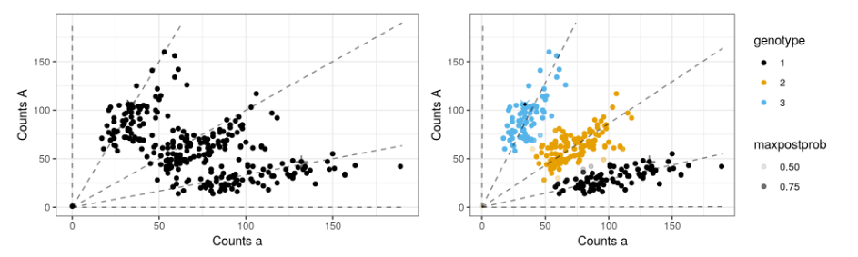

Good SNP

Below one example of large`bias` with `updog` fitted with parental information (`f1` model) and withou parental information (`norm` model). In this example, we used the `flexdog()` function, that is the same function of `multidog()`, but not in the parallel version.

```r
# F1 model
uout <- flexdog(refvec = oref[snp,],
          sizevec = osize[snp,],
          p1ref = oref[snp,"PAT_194201_P003_WH10"], # Information from the parental 1
          p1size=osize[snp,"PAT_194201_P003_WH10"],
          p2ref = oref[snp,"PAT_194201_P003_WH12"], # Information from the parental 2
          p2size=osize[snp,"PAT_194201_P003_WH12"],
          model   = "f1",
          ploidy = 4, verbose=F)

uout2 <- flexdog(refvec = oref[snp,],
          sizevec = osize[snp,],
          model   = "norm",
          ploidy = 4, verbose=F)
```

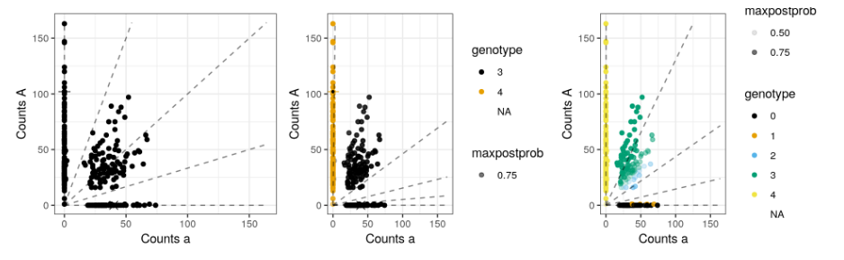

Large bias

**Some notes**

# Final notes

- In diploids there is only one type of heterozygote, in polyploids there are multiple
- Raw data from sequencing (read counts) or arrays (signal intensities) must be converted to allele dosages to be used in downstream analyses
- Several software packages available
- Genotyping array:
  - Allele are labelled with a different colors
  - Fluorescence of both labels measured
  - Example: KASP markers, Sequenom MASSArray, Illumina GoldenGate and others
  - Software: [fitPoly (fitTetra)](https://github.com/cran/fitPoly), [SuperMASSA](https://statgen.esalq.usp.br/SuperMASSA/) and [ClusterCall](https://potatobreeding.cals.wisc.edu/software/)
- Sequencing data:
  - Software: updog and [polyRAD](https://github.com/lvclark/polyRAD#tutorial)

## Blueberry Genome

- Important information for blueberry studies.
- Haplotype-phased blueberry genome was published by [Colle et al., (2019)](https://academic.oup.com/gigascience/article/8/3/giz012/5304886).
- So far, all genotype calling has been performed based on this reference genome in our group.
- Other reference genomes in blueberry are trying to follow the same nomenclature to define the chromosomes
- Chromosome-scale are divided into main scaffolds and the convertion into chromosomes is presented below:

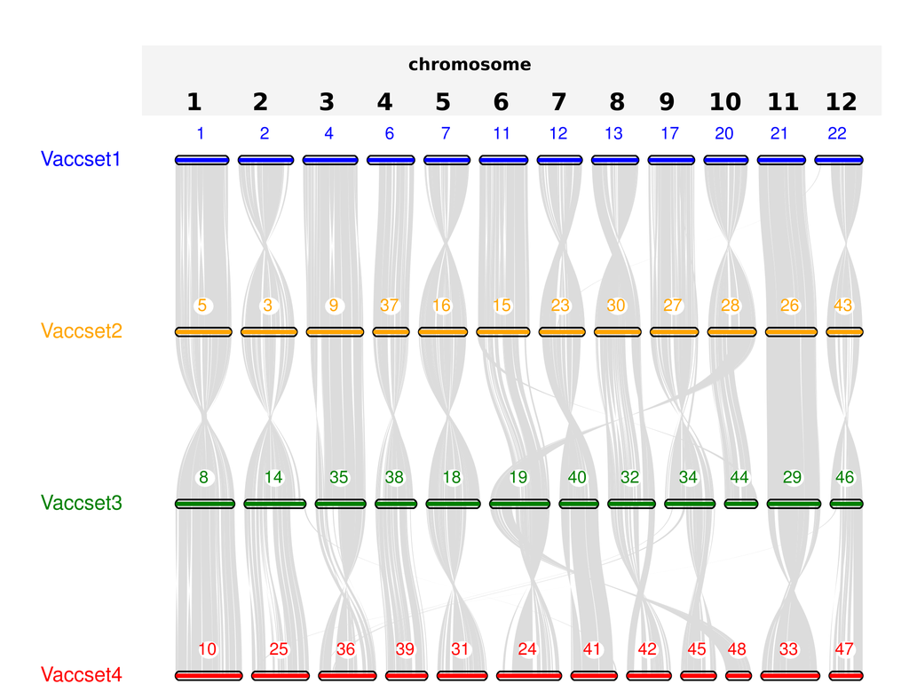

Blueberry chromosomes and their association with the scaffold information

# References

- Benevenuto, J; Ferrão, LFV; Amadeu, RR; Munoz, PR; How can a high-quality genome assembly help plant breeders?. [Link](https://academic.oup.com/gigascience/article/8/6/giz068/5513659?guestAccessKey=6ff2ddb4-148b-44a7-970a-1c1a9f394200&login=true)
- Gerard, D and Ferrão, LFV. Priors for Genotyping Polyploids. Bioinformatics, 2019.[Link](https://academic.oup.com/bioinformatics/article/36/6/1795/5625617?login=true)
- Gerard, D; Ferrão, LFV; Garcia, AAF; Stephens, M. Genotyping Polyploids from Messy Sequencing Data. Genetics, Vol. 210, 789–807, 2018. [Link](https://academic.oup.com/genetics/article/210/3/789/5931034?etoc)

[figure not shown]